# 7) Fitting QTPME Models to the rsEEG Data

2026-07-01

```r
knitr::opts_chunk$set(echo = FALSE)
knitr::opts_chunk$set(message = FALSE)
knitr::opts_chunk$set(comment = NULL)
knitr::opts_chunk$set(warning = FALSE)
```

```r
# Load in the package
library(tidyverse)
library(ggplot2)
library(patchwork)
library(nlme)
library(nlraa)
```

### Specifying the factors

Here we will be specifying the factors of our model so that we know how to interpret the intercept and the effects essentially. In our current dataset, there are 6 categorical variables:

- ID
- FB
- Sex _ Spell_group
- region
- hemisphere

These will be the function of each one:

- ID (don’t matter), used to model the random intercepts, we don’t care about the class of this variable
- FB (don’t matter), will be split by unique levels of the variable, we don’t care about the class of this variable
- Sex (**dummy coded**), will be used for the analysis but will only function as a main effect. We can have the reference as female
- Spell_group (**dummy coded**), is our main predictor of interest, we should have the reference as good so that we estimate the effect of poor and leave it as.
- region (**effect coded**), there are 5 regions and keeping it dummy coded will produce effects compared to the reference, will be much more informative to use effect coding instead. The interpretation will change to the grand average of the region levels.
- hemisphere (**effect coded**), while it is a dichotmous variable and leaving it as dummy coded will make us know the power difference between the levels, the hemisphere interactions will make this difficulty, so it might be better to just have it as effect coded, so that it also represents an average of the two levels.

```
[1] "central"   "frontal"   "occipital" "parietal"  "temporal"
```

```
          central frontal occipital parietal
central         1       0         0        0
frontal         0       1         0        0
occipital       0       0         1        0
parietal        0       0         0        1
temporal       -1      -1        -1       -1
```

```
      left
left     1
right   -1
```

```
The min age of the sample is 15
```

### Simulate three potential outcomes for our data

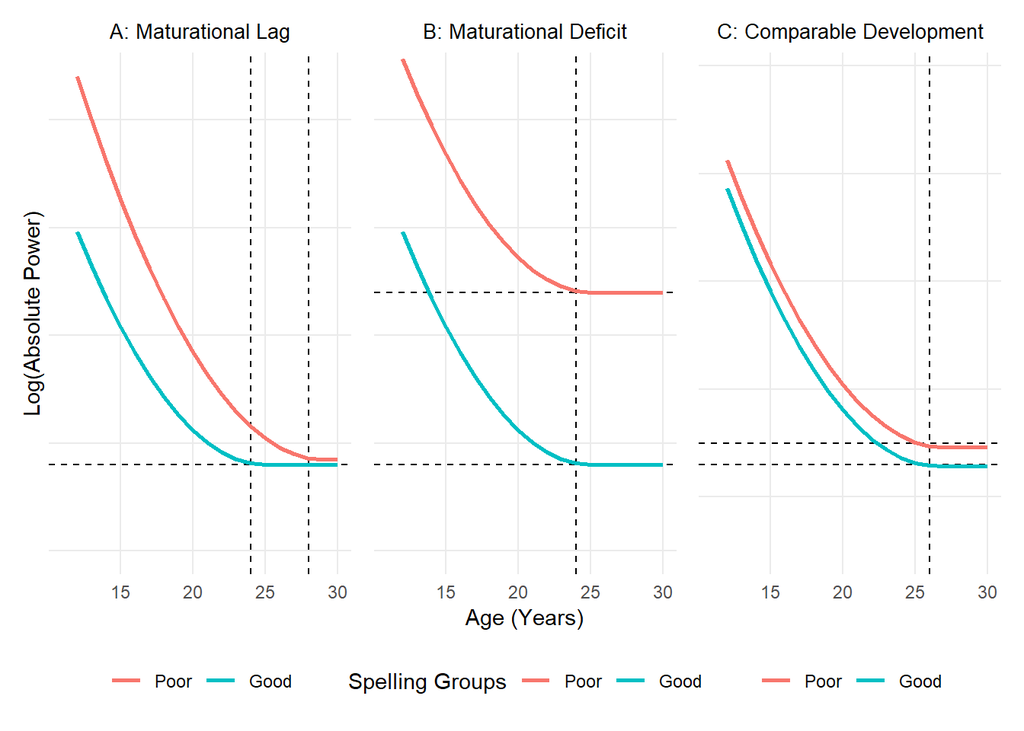

### Initial Fitting of a QTPME for Delta

So this is essentially what fitting a quadratic to plateau mixed effects (QTPME) model looks like. Basically there is a lot going on so lets break it down. Starting first, the QTPME is a **non-linear** mixed-effects model, so we will be using the `nlme()` function to specify this. When working with non-linear models, we also need to provide two more sources of information: the model rules and the starting values.

For the model rules, that is basically the Quadratic to Plateau part, which we specify using the SSquadp3xs() function. Next, for the starting values, we are basically picking values that make sense to us, down below we chose:

- intercept = 3
- slope = - 4
- join point = 28

We chose these arbitrarily and the model still ran- so that’s a good thing however there is the risk that our first set of starting values will produce an error, which will mean we will need to try a new set and hope that works.

In addition to this, there is the ‘fixed’ argument in the formula where we tell the model what fixed effects we want for each of the three parameters below: a, b, xs. To make things more confusing is the start argument.

```r
mod <- nlme(log_absolute_power ~ SSquadp3xs(Age_min_c, a, b, xs),
                        data = delta_dat,
                        fixed = list(a ~ Sex + hemisphere + region + Spell_group,
                                     b ~ Spell_group,
                                     xs ~ Spell_group),
                        random = a ~ 1 | ID,
                        start = c(a = 3, rep(0, 1 + 1 + 4 + 1 + 1 - 1),
                                   b = -4, 0,
                                   xs = 28, 0),
                        control = nlmeControl(msMaxIter = 2000))

mod
```

```
Nonlinear mixed-effects model fit by maximum likelihood
  Model: log_absolute_power ~ SSquadp3xs(Age_min_c, a, b, xs)
  Data: delta_dat
  Log-likelihood: -1240.239
  Fixed: list(a ~ Sex + hemisphere + region + Spell_group, b ~ Spell_group,      xs ~ Spell_group)
    a.(Intercept)            a.SexM  a.hemisphereleft   a.regioncentral   a.regionfrontal a.regionoccipital  a.regionparietal  a.Spell_grouplow
      1.930296804      -0.010062409      -0.005364699      -0.599499193       0.147483782       0.231722373      -0.047192839      -0.029074562
    b.(Intercept)  b.Spell_grouplow    xs.(Intercept) xs.Spell_grouplow
     -0.099629188      -0.008930036      13.049394644       2.919803043

Random effects:
 Formula: a ~ 1 | ID
        a.(Intercept)  Residual
StdDev:     0.4062864 0.3157198

Number of Observations: 3030
Number of Groups: 303
```

### Introducing the Custom Functions to Run QTPME Models

Below we are introducing two custom functions that are basically going to make our lives extremely easy. The first one takes in a ‘formula_list’, which is a specific list object that contains the formulas to specify the fixed effects of the three parameters, the dataset, and the chosen starting values (this is manual as is). Basically this function returns the starting value vectors that are needed in the ‘start’ argument. What is great is that it can do this for specified models that only include main effects and those that include interactions!

The next custom function runs the QTPME using the information from the ‘formula_list’ and the starting value vectors. The QTPME will automatically run using Age_min_c as a predictor.

**Imporant**: The first time running the functions everything worked no problem! However, as they were, the ouput was incompatible with emmeans(), because of how emmeans used the model object information to recreate stuff. Fortunately, we were able to identify the problems, which was the way the model$call was being saved and we wrote additional lines of code in the fit_QTPME() function that now fixes it!

```r
# Function 1: creating a custom function to generate a list of starting values
gen_start_vectors <- function(formula_list) {

  # 1. Stitch the DV to the one-sided formulas using update()
  form_a  <- update(formula_list$formula_a,  log_absolute_power ~ .)
  form_b  <- update(formula_list$formula_b,  log_absolute_power ~ .)
  form_xs <- update(formula_list$formula_xs, log_absolute_power ~ .)

  # 2. Run the dummy linear models
  mod_a  <- lm(form_a,  data = formula_list$data)
  mod_b  <- lm(form_b,  data = formula_list$data)
  mod_xs <- lm(form_xs, data = formula_list$data)

  # 3. Calculate the parameter numbers
  param_num_a <- length(coef(mod_a)) - 1
  param_num_b <- length(coef(mod_b)) - 1
  param_num_xs <-  length(coef(mod_xs)) - 1

  # 4. Create the starting value vectors
  list(
    start_val_a = c(formula_list$starting_vals["a"], rep(0, param_num_a)),
    start_val_b = c(formula_list$starting_vals["b"], rep(0, param_num_b)),
    start_val_xs = c(formula_list$starting_vals["xs"], rep(0, param_num_xs))
  )
}

# Function 2: Create a custom function to fit a QTP model
fit_QTPME <- function(formula_list, QTP_start) {

  # Dynamically construct the named, two-sided formula strings nlme expects
  fixed_a  <- as.formula(paste("a",  paste(deparse(formula_list$formula_a),  collapse="")))
  fixed_b  <- as.formula(paste("b",  paste(deparse(formula_list$formula_b),  collapse="")))
  fixed_xs <- as.formula(paste("xs", paste(deparse(formula_list$formula_xs), collapse="")))

  mod <- nlme(log_absolute_power ~ SSquadp3xs(Age_min_c, a, b, xs), # Age centered at youngest age in sample
       data = formula_list$data,
       fixed = list(fixed_a, fixed_b, fixed_xs), # Now properly formatted as a ~ ..., b ~ ...
       random = a ~ 1 | ID,
       start = c(a = QTP_start$start_val_a,
                 b = QTP_start$start_val_b,
                 xs = QTP_start$start_val_xs),
       control = nlmeControl(msMaxIter = 2000))

  ## ---- repair the stored call ----
  mod$call$fixed <- eval(substitute(
    list(A, B, C),
    list(
      A = fixed_a,
      B = fixed_b,
      C = fixed_xs
    )
  ))

  ## store the actual data in the model object
  mod$data <- formula_list$data

  ## point the call to the stored data
  mod$call$data <- quote(mod$data)

  # Return the model
  return(mod)
}
```

### MVP Custom Function

This is the MVP custom function! Similar to what we did in the Creating Spelling Groups .html, here we asked AI to basically generate us a function that will identify starting values that will produce model convergence. We will only use this function if our initial starting values that were manually chosen end up failing, which is the case in **alpha1**.

```r
fit_QTPME_grid <- function(formula_list,
                           a_vals = seq(1, 5, by = 1),
                           b_vals = seq(-8, 2, by = 1),
                           xs_vals = seq(20, 32, by = 1)) {

  starts <- expand.grid(
    a0 = a_vals,
    b0 = b_vals,
    xs0 = xs_vals
  )

  for(i in seq_len(nrow(starts))) {

    cat(
      "Trying:",
      "a =", starts$a0[i],
      "b =", starts$b0[i],
      "xs =", starts$xs0[i], "\n"
    )

    tmp_formula <- formula_list

    tmp_formula$starting_vals <- c(
      a  = starts$a0[i],
      b  = starts$b0[i],
      xs = starts$xs0[i]
    )

    start_vec <- gen_start_vectors(tmp_formula)

    fit <- try(
      fit_QTPME(tmp_formula, start_vec),
      silent = TRUE
    )

    if(!inherits(fit, "try-error")) {

      cat(
        "\nSuccessful fit!\n",
        "a =", starts$a0[i],
        "b =", starts$b0[i],
        "xs =", starts$xs0[i], "\n"
      )

      return(
        list(
          fit = fit,
          starts = starts[i, ]
        )
      )
    }
  }

  stop("No starting values converged.")
}
```

### Running QTPME Models for Delta

We will show the code just for delta but the same thing will also be done for theta and alpha1.

```r
# 1. Main effects only model
formula_list_main <- list(
  formula_a = ~ Sex + hemisphere + region + Spell_group,
  formula_b = ~ Spell_group,
  formula_xs = ~ Spell_group,
  data = delta_dat,
  starting_vals = c(a = 3, b = -4, xs = 28)
)

# 2. Add topographic interaction
formula_list_regionHemisphere <- list(
  formula_a = ~ Sex + hemisphere + region + Spell_group + hemisphere:region,
  formula_b = ~ Spell_group,
  formula_xs = ~ Spell_group,
  data = delta_dat,
  starting_vals = c(a = 3, b = -4, xs = 28)
)

# 3. Add the spelling related two-way interactions
formula_list_spelling2way <- list(
  formula_a = ~ Sex + hemisphere + region + Spell_group + hemisphere:region + hemisphere:Spell_group + region:Spell_group,
  formula_b = ~ Spell_group,
  formula_xs = ~ Spell_group,
  data = delta_dat,
  starting_vals = c(a = 3, b = -4, xs = 28)
)

# 4. Add the full three-way interaction
formula_list_spelling3way <- list(
  formula_a = ~ Sex + region*Spell_group*hemisphere,
  formula_b = ~ Spell_group,
  formula_xs = ~ Spell_group,
  data = delta_dat,
  starting_vals = c(a = 3, b = -4, xs = 28)

)


# Step2: Generate the starting values
QTP_start_main <- gen_start_vectors(formula_list_main)
QTP_start_regionHemisphere <- gen_start_vectors(formula_list_regionHemisphere)
QTP_start_spelling2way <- gen_start_vectors(formula_list_spelling2way)
QTP_start_spelling3way <- gen_start_vectors(formula_list_spelling3way)

# Step 3: Fit the QTPME
delta_QTPME1 <- fit_QTPME(formula_list_main, QTP_start_main)
delta_QTPME2 <- fit_QTPME(formula_list_regionHemisphere, QTP_start_regionHemisphere)
delta_QTPME3 <- fit_QTPME(formula_list_spelling2way, QTP_start_spelling2way)
delta_QTPME4 <- fit_QTPME(formula_list_spelling3way, QTP_start_spelling3way)

# Does the interactions on the intercept improve model fit?
anova(delta_QTPME1, delta_QTPME2, delta_QTPME3, delta_QTPME4)
```

```
             Model df      AIC      BIC    logLik   Test  L.Ratio p-value
delta_QTPME1     1 14 2508.478 2592.706 -1240.239
delta_QTPME2     2 18 2470.138 2578.432 -1217.069 1 vs 2 46.33949  <.0001
delta_QTPME3     3 23 2473.820 2612.195 -1213.910 2 vs 3  6.31829  0.2765
delta_QTPME4     4 27 2471.719 2634.160 -1208.860 3 vs 4 10.10068  0.0388
```

```r
# Create lists with the model outputs
delta_mods <- list(
  mod1 = delta_QTPME1,
  mod2 = delta_QTPME2,
  mod3 = delta_QTPME3,
  mod4 = delta_QTPME4
)
```

### Running QTPME Models for Theta

```
             Model df      AIC      BIC    logLik   Test  L.Ratio p-value
theta_QTPME1     1 14 2676.245 2760.473 -1324.122
theta_QTPME2     2 18 2652.016 2760.309 -1308.008 1 vs 2 32.22885  <.0001
theta_QTPME3     3 23 2655.003 2793.379 -1304.502 2 vs 3  7.01226  0.2197
theta_QTPME4     4 27 2655.677 2818.118 -1300.839 3 vs 4  7.32610  0.1196
```

### Running QTPME Models for Alpha1

```r
# Step 3: Fit the QTPME
try(alpha1_QTPME1 <- fit_QTPME(formula_list_main, QTP_start_main))
```

```
Error in nlme.formula(log_absolute_power ~ SSquadp3xs(Age_min_c, a, b,  :
  Singularity in backsolve at level 0, block 1
```

```r
try(alpha1_QTPME2 <- fit_QTPME(formula_list_regionHemisphere, QTP_start_regionHemisphere))
```

```
Error in nlme.formula(log_absolute_power ~ SSquadp3xs(Age_min_c, a, b,  :
  Singularity in backsolve at level 0, block 1
```

```r
try(alpha1_QTPME3 <- fit_QTPME(formula_list_spelling2way, QTP_start_spelling2way))
```

```
Error in nlme.formula(log_absolute_power ~ SSquadp3xs(Age_min_c, a, b,  :
  Singularity in backsolve at level 0, block 1
```

```r
try(alpha1_QTPME4 <- fit_QTPME(formula_list_spelling3way, QTP_start_spelling3way))
```

```
Error in nlme.formula(log_absolute_power ~ SSquadp3xs(Age_min_c, a, b,  :
  Singularity in backsolve at level 0, block 1
```

The first time using fit_QTPME_grid() can take a long time, because you are giving it a wide range of values to investigate in order to get convergence. However, once it converges you know what those starting values are! Thus, here these models should be quick because we modified their starting values to be very close to the ones that led to an initial convergence.

```r
# Use the fit_QTPME_grid() function on the formula lists created above
alpha_QTPME1_list <- fit_QTPME_grid(
  formula_list_main,
  a_vals  = seq(-0.5, 1.0, by=.25),
  b_vals  = seq(-0.05, 0.05, by=.025),
  xs_vals = seq(19, 30, by=1)
)
```

[output not shown]

[output cut: 26 more lines]

```
Trying: a = 0.25 b = 0.05 xs = 20
Trying: a = 0.5 b = 0.05 xs = 20
Trying: a = 0.75 b = 0.05 xs = 20
Trying: a = 1 b = 0.05 xs = 20
Trying: a = -0.5 b = -0.05 xs = 21
Trying: a = -0.25 b = -0.05 xs = 21
Trying: a = 0 b = -0.05 xs = 21
Trying: a = 0.25 b = -0.05 xs = 21
Trying: a = 0.5 b = -0.05 xs = 21
Trying: a = 0.75 b = -0.05 xs = 21
Trying: a = 1 b = -0.05 xs = 21
Trying: a = -0.5 b = -0.025 xs = 21

Successful fit!
 a = -0.5 b = -0.025 xs = 21
```

```r
alpha_QTPME2_list <- fit_QTPME_grid(
  formula_list_regionHemisphere,
  a_vals  = seq(-0.5, 1.0, by=.25),
  b_vals  = seq(-0.05, 0.05, by=.025),
  xs_vals = seq(19, 30, by=1)
)
```

[output not shown]

[output cut: 26 more lines]

```
Trying: a = 0.25 b = 0.05 xs = 20
Trying: a = 0.5 b = 0.05 xs = 20
Trying: a = 0.75 b = 0.05 xs = 20
Trying: a = 1 b = 0.05 xs = 20
Trying: a = -0.5 b = -0.05 xs = 21
Trying: a = -0.25 b = -0.05 xs = 21
Trying: a = 0 b = -0.05 xs = 21
Trying: a = 0.25 b = -0.05 xs = 21
Trying: a = 0.5 b = -0.05 xs = 21
Trying: a = 0.75 b = -0.05 xs = 21
Trying: a = 1 b = -0.05 xs = 21
Trying: a = -0.5 b = -0.025 xs = 21

Successful fit!
 a = -0.5 b = -0.025 xs = 21
```

```r
alpha_QTPME3_list <- fit_QTPME_grid(
  formula_list_spelling2way,
  a_vals  = seq(-0.5, 1.0, by=.25),
  b_vals  = seq(-0.05, 0.05, by=.025),
  xs_vals = seq(19, 30, by=1)
)
```

[output not shown]

[output cut: 26 more lines]

```
Trying: a = 0.25 b = 0.05 xs = 20
Trying: a = 0.5 b = 0.05 xs = 20
Trying: a = 0.75 b = 0.05 xs = 20
Trying: a = 1 b = 0.05 xs = 20
Trying: a = -0.5 b = -0.05 xs = 21
Trying: a = -0.25 b = -0.05 xs = 21
Trying: a = 0 b = -0.05 xs = 21
Trying: a = 0.25 b = -0.05 xs = 21
Trying: a = 0.5 b = -0.05 xs = 21
Trying: a = 0.75 b = -0.05 xs = 21
Trying: a = 1 b = -0.05 xs = 21
Trying: a = -0.5 b = -0.025 xs = 21

Successful fit!
 a = -0.5 b = -0.025 xs = 21
```

```r
alpha_QTPME4_list <- fit_QTPME_grid(
  formula_list_spelling3way,
  a_vals  = seq(-0.5, 1.0, by=.25),
  b_vals  = seq(-0.05, 0.05, by=.025),
  xs_vals = seq(19, 30, by=1)
)
```

[output not shown]

[output cut: 26 more lines]

```
Trying: a = 0.25 b = 0.05 xs = 20
Trying: a = 0.5 b = 0.05 xs = 20
Trying: a = 0.75 b = 0.05 xs = 20
Trying: a = 1 b = 0.05 xs = 20
Trying: a = -0.5 b = -0.05 xs = 21
Trying: a = -0.25 b = -0.05 xs = 21
Trying: a = 0 b = -0.05 xs = 21
Trying: a = 0.25 b = -0.05 xs = 21
Trying: a = 0.5 b = -0.05 xs = 21
Trying: a = 0.75 b = -0.05 xs = 21
Trying: a = 1 b = -0.05 xs = 21
Trying: a = -0.5 b = -0.025 xs = 21

Successful fit!
 a = -0.5 b = -0.025 xs = 21
```

```r
# Extracting the model from the list objects
alpha_QTPME1 <- alpha_QTPME1_list$fit
alpha_QTPME2 <- alpha_QTPME2_list$fit
alpha_QTPME3 <- alpha_QTPME3_list$fit
alpha_QTPME4 <- alpha_QTPME4_list$fit

# Does the interactions on the intercept improve model fit?
anova(alpha_QTPME1, alpha_QTPME2, alpha_QTPME3, alpha_QTPME4)
```

```
             Model df      AIC      BIC    logLik   Test  L.Ratio p-value
alpha_QTPME1     1 14 4349.876 4434.105 -2160.938
alpha_QTPME2     2 18 4283.386 4391.680 -2123.693 1 vs 2 74.48976  <.0001
alpha_QTPME3     3 23 4282.604 4420.979 -2118.302 2 vs 3 10.78248  0.0559
alpha_QTPME4     4 27 4280.075 4442.515 -2113.037 3 vs 4 10.52930  0.0324
```

```r
# Create lists with the model outputs
alpha1_mods <- list(
  mod1 = alpha_QTPME1,
  mod2 = alpha_QTPME2,
  mod3 = alpha_QTPME3,
  mod4 = alpha_QTPME4
)
```